# Churn Data Analysis

## Scenario: Telecommunications Churn

In the telecommunications industry, customers can choose from multiple service providers and actively switch from one provider to another. Customer “churn” is defined as the percentage of customers who stopped using a provider’s product or service during a certain time frame. In this highly competitive market, some telecommunications industries can experience average annual churn rates as high as 25 percent. Given that it costs 10 times more to acquire a new customer than to retain an existing one, customer retention has now become even more important than customer acquisition.

For many providers, retaining highly profitable customers is the number one business goal. To reduce customer churn, telecommunications companies need to predict which customers are at high risk of churn.

## Introduction

An organization has collected raw data to analyze its operations and support its decision-making processes. The raw data files from the Data Cleaning course have been cleaned and prepared for exploratory analysis.

To compete this assessment, you will access a data dictionary file and its corresponding data flat file. You will analyze the data set using specific techniques, create visualizations, and deliver the results of your analysis.

## Information

Full github profile for this project can be seen [Here](https://github.com/TrikerDev/Exploratory-Data-Analysis-D207). The raw data being used for this analysis can be seen [Here](https://github.com/TrikerDev/Exploratory-Data-Analysis-D207/blob/main/Cleaned%20Churn%20Data/churn_clean.csv). Data Dictionary for all variables can be seen listed below and [Here](https://github.com/TrikerDev/Exploratory-Data-Analysis-D207/blob/main/Cleaned%20Churn%20Data/D207%20D208%20D209%20Churn%20Data%20Consideration%20and%20Dictionary.pdf).

## Data Dictionary:

The data set includes the following information:

• customers who left within the last month (the “Churn” column)

• services that each customer signed up for (phone, multiple lines, internet, online security, online backup, device protection, technical support, and streaming TV and movies)

• customer account information (how long they’ve been a customer, contracts, payment methods, paperless billing, monthly charges, GB usage over a year, etc.)

• customer demographics (gender, age, job, income, etc.)

The data set consists of 10,000 customers and 50 columns/variables:

• CaseOrder: A placeholder variable to preserve the original order of the raw data file

• Customer_id: Unique customer ID

• Interaction, UID: Unique IDs related to customer transactions, technical support, and sign-ups

The following variables represent customer demographic data:

o City: Customer city of residence as listed on the billing statement

o State: Customer state of residence as listed on the billing statement

o County: Customer county of residence as listed on the billing statement

o Zip: Customer zip code of residence as listed on the billing statement

o Lat, Lng: GPS coordinates of customer residence as listed on the billing statement

o Population: Population within a mile radius of customer, based on census data

o Area: Area type (rural, urban, suburban), based on census data

o TimeZone: Time zone of customer residence based on customer’s sign-up information

o Job: Job of the customer (or invoiced person) as reported in sign-up information

o Children: Number of children in customer’s household as reported in sign-up information

o Age: Age of customer as reported in sign-up information

o Education: Highest degree earned by customer as reported in sign-up information

o Employment: Employment status of customer as reported in sign-up information

o Income: Annual income of customer as reported at time of sign-up

o Marital: Marital status of customer as reported in sign-up information

o Gender: Customer self-identification as male, female, or nonbinary

• Churn: Whether the customer discontinued service within the last month (yes, no)

• Outage_sec_perweek: Average number of seconds per week of system outages in the customer’s neighborhood

• Email: Number of emails sent to the customer in the last year (marketing or correspondence)

• Contacts: Number of times customer contacted technical support

• Yearly_equip_failure: The number of times customer’s equipment failed and had to be reset/replaced in the past year

• Techie: Whether the customer considers themselves technically inclined (based on customer questionnaire when they signed up for services) (yes, no)

• Contract: The contract term of the customer (month-to-month, one year, two year)

• Port_modem: Whether the customer has a portable modem (yes, no)

• Tablet: Whether the customer owns a tablet such as iPad, Surface, etc. (yes, no)

• InternetService: Customer’s internet service provider (DSL, fiber optic, None)

• Phone: Whether the customer has a phone service (yes, no)

• Multiple: Whether the customer has multiple lines (yes, no)

• OnlineSecurity: Whether the customer has an online security add-on (yes, no)

• OnlineBackup: Whether the customer has an online backup add-on (yes, no)

• DeviceProtection: Whether the customer has device protection add-on (yes, no)

• TechSupport: Whether the customer has a technical support add-on (yes, no)

• StreamingTV: Whether the customer has streaming TV (yes, no)

• StreamingMovies: Whether the customer has streaming movies (yes, no)

• PaperlessBilling: Whether the customer has paperless billing (yes, no)

• PaymentMethod: The customer’s payment method (electronic check, mailed check, bank (automatic bank transfer), credit card (automatic))

• Tenure: Number of months the customer has stayed with the provider

• MonthlyCharge: The amount charged to the customer monthly. This value reflects an average per customer.

• Bandwidth_GB_Year: The average amount of data used, in GB, in a year by the customer

The following variables represent responses to an eight-question survey asking customers to rate the importance of various factors/surfaces on a scale of 1 to 8 (1 = most important, 8 = least important)

o Item1: Timely response

o Item2: Timely fixes

o Item3: Timely replacements

o Item4: Reliability

o Item5: Options

o Item6: Respectful response

o Item7: Courteous exchange

o Item8: Evidence of active listening

## Question

> What are the affects of tenure and GB usage on churn rate?

> Stakeholders in the organization would benefit from an analysis of the data because an analysis brings actionable insights that the company can make use of to improve business function. For example, they can find what factors greatly correlate and contribute to customer churn rate, and the organization can work on fixing those issues to lower the churn rate.

> The data needed for this analysis is Bandwidth_GB_Year, Tenure, and Churn.

```python
# Importing the packages that will be used for this analysis
import pandas as pd
import numpy as np
import matplotlib.pyplot as plt
import seaborn as sns
from scipy.stats import ttest_ind
%matplotlib inline
```

```python
# Loading in our dataset in the form of a Pandas DataFrame. We name the variable 'df' for DataFrame.
df = pd.read_csv('Cleaned Churn Data\churn_clean.csv')

# Displaying the first few rows of df to make sure it imported correctly
df.head()
```

|  | CaseOrder | Customer_id | Interaction | UID | City | State | County | Zip | Lat | Lng | ... | MonthlyCharge | Bandwidth_GB_Year | Item1 | Item2 | Item3 | Item4 | Item5 | Item6 | Item7 | Item8 |
| --- | --- | --- | --- | --- | --- | --- | --- | --- | --- | --- | --- | --- | --- | --- | --- | --- | --- | --- | --- | --- | --- |
| 0 | 1 | K409198 | aa90260b-4141-4a24-8e36-b04ce1f4f77b | e885b299883d4f9fb18e39c75155d990 | Point Baker | AK | Prince of Wales-Hyder | 99927 | 56.25100 | -133.37571 | ... | 172.455519 | 904.536110 | 5 | 5 | 5 | 3 | 4 | 4 | 3 | 4 |
| 1 | 2 | S120509 | fb76459f-c047-4a9d-8af9-e0f7d4ac2524 | f2de8bef964785f41a2959829830fb8a | West Branch | MI | Ogemaw | 48661 | 44.32893 | -84.24080 | ... | 242.632554 | 800.982766 | 3 | 4 | 3 | 3 | 4 | 3 | 4 | 4 |
| 2 | 3 | K191035 | 344d114c-3736-4be5-98f7-c72c281e2d35 | f1784cfa9f6d92ae816197eb175d3c71 | Yamhill | OR | Yamhill | 97148 | 45.35589 | -123.24657 | ... | 159.947583 | 2054.706961 | 4 | 4 | 2 | 4 | 4 | 3 | 3 | 3 |
| 3 | 4 | D90850 | abfa2b40-2d43-4994-b15a-989b8c79e311 | dc8a365077241bb5cd5ccd305136b05e | Del Mar | CA | San Diego | 92014 | 32.96687 | -117.24798 | ... | 119.956840 | 2164.579412 | 4 | 4 | 4 | 2 | 5 | 4 | 3 | 3 |
| 4 | 5 | K662701 | 68a861fd-0d20-4e51-a587-8a90407ee574 | aabb64a116e83fdc4befc1fbab1663f9 | Needville | TX | Fort Bend | 77461 | 29.38012 | -95.80673 | ... | 149.948316 | 271.493436 | 4 | 4 | 4 | 3 | 4 | 4 | 4 | 5 |

5 rows × 50 columns

```python
# Correlation between all variables
df.corr()
```

|  | CaseOrder | Zip | Lat | Lng | Population | Children | Age | Income | Outage_sec_perweek | Email | ... | MonthlyCharge | Bandwidth_GB_Year | Item1 | Item2 | Item3 | Item4 | Item5 | Item6 | Item7 | Item8 |
| --- | --- | --- | --- | --- | --- | --- | --- | --- | --- | --- | --- | --- | --- | --- | --- | --- | --- | --- | --- | --- | --- |
| CaseOrder | 1.000000 | 3.007020e-03 | -0.014680 | -0.001363 | -0.007494 | -0.006148 | 0.016038 | 0.000192 | -0.001358 | -0.011274 | ... | 0.003677 | 0.825561 | -0.004318 | 0.005959 | 0.003245 | -5.640975e-03 | 0.016429 | -0.007837 | 0.003595 | -0.014840 |
| Zip | 0.003007 | 1.000000e+00 | -0.042580 | -0.901786 | 0.045138 | -0.017205 | -0.008135 | 0.002947 | -0.011520 | -0.007860 | ... | -0.008717 | -0.002527 | -0.026024 | -0.003215 | -0.019687 | 6.196497e-07 | 0.002923 | 0.007375 | -0.005537 | -0.002577 |
| Lat | -0.014680 | -4.257985e-02 | 1.000000 | -0.100639 | -0.220598 | -0.000452 | -0.002943 | 0.006563 | 0.004827 | -0.030042 | ... | 0.001406 | -0.016949 | 0.005793 | 0.005380 | -0.003421 | 1.101487e-02 | -0.000464 | -0.008726 | 0.006087 | -0.019583 |
| Lng | -0.001363 | -9.017856e-01 | -0.100639 | 1.000000 | -0.048294 | 0.013634 | 0.012117 | -0.002997 | 0.005646 | 0.007872 | ... | 0.011765 | 0.003446 | 0.024389 | 0.003024 | 0.014966 | -2.397805e-03 | 0.001366 | -0.008770 | 0.001601 | 0.001912 |
| Population | -0.007494 | 4.513808e-02 | -0.220598 | -0.048294 | 1.000000 | -0.005877 | 0.010538 | -0.008639 | 0.005483 | 0.017962 | ... | -0.004778 | -0.003902 | 0.000618 | -0.002571 | 0.001620 | -8.272481e-03 | 0.006970 | 0.000834 | -0.013062 | 0.008524 |
| Children | -0.006148 | -1.720505e-02 | -0.000452 | 0.013634 | -0.005877 | 1.000000 | -0.029732 | 0.009942 | 0.001889 | 0.004479 | ... | -0.009781 | 0.025585 | 0.011470 | 0.013146 | 0.003394 | -1.676831e-02 | -0.000240 | -0.000547 | 0.000687 | -0.005236 |
| Age | 0.016038 | -8.135285e-03 | -0.002943 | 0.012117 | 0.010538 | -0.029732 | 1.000000 | -0.004091 | -0.008047 | 0.001588 | ... | 0.010729 | -0.014724 | -0.005972 | 0.006659 | -0.003778 | 1.223656e-02 | -0.008305 | 0.010635 | 0.005353 | 0.015193 |
| Income | 0.000192 | 2.946523e-03 | 0.006563 | -0.002997 | -0.008639 | 0.009942 | -0.004091 | 1.000000 | -0.010011 | -0.009267 | ... | -0.003014 | 0.003674 | -0.004009 | 0.007718 | -0.002707 | -2.274962e-02 | 0.011111 | 0.001768 | 0.016599 | 0.000740 |
| Outage_sec_perweek | -0.001358 | -1.152040e-02 | 0.004827 | 0.005646 | 0.005483 | 0.001889 | -0.008047 | -0.010011 | 1.000000 | 0.003994 | ... | 0.020496 | 0.004176 | -0.023338 | -0.008076 | -0.021366 | -5.992006e-03 | -0.004156 | -0.014752 | -0.020854 | 0.008126 |
| Email | -0.011274 | -7.860018e-03 | -0.030042 | 0.007872 | 0.017962 | 0.004479 | 0.001588 | -0.009267 | 0.003994 | 1.000000 | ... | 0.001997 | -0.014579 | 0.003709 | 0.001156 | 0.012928 | 9.150354e-04 | -0.007929 | 0.014468 | 0.010010 | -0.005857 |
| Contacts | 0.004361 | -4.719513e-03 | -0.002213 | 0.008118 | 0.004019 | -0.020776 | 0.015068 | 0.001233 | 0.015092 | 0.003040 | ... | 0.004259 | 0.003299 | -0.007364 | -0.003003 | -0.021924 | 1.070637e-03 | 0.004698 | -0.000994 | 0.004579 | -0.012615 |
| Yearly_equip_failure | 0.005497 | 1.104692e-02 | -0.007125 | -0.005577 | -0.004483 | 0.007321 | 0.008577 | 0.005423 | 0.002909 | -0.016354 | ... | -0.007172 | 0.012034 | 0.007518 | -0.009773 | -0.009372 | -6.906269e-03 | 0.003416 | -0.003995 | -0.010368 | -0.009859 |
| Tenure | 0.832550 | -3.227133e-03 | -0.015743 | 0.003618 | -0.003559 | -0.005091 | 0.016979 | 0.002114 | 0.002932 | -0.014468 | ... | -0.003337 | 0.991495 | -0.006246 | 0.003073 | 0.002351 | -6.714154e-03 | 0.024618 | -0.010127 | 0.000410 | -0.016347 |
| MonthlyCharge | 0.003677 | -8.716780e-03 | 0.001406 | 0.011765 | -0.004778 | -0.009781 | 0.010729 | -0.003014 | 0.020496 | 0.001997 | ... | 1.000000 | 0.060406 | 0.009756 | 0.003442 | -0.008487 | -4.400525e-04 | -0.005562 | 0.002943 | -0.006399 | 0.002204 |
| Bandwidth_GB_Year | 0.825561 | -2.527196e-03 | -0.016949 | 0.003446 | -0.003902 | 0.025585 | -0.014724 | 0.003674 | 0.004176 | -0.014579 | ... | 0.060406 | 1.000000 | -0.007314 | 0.003062 | 0.000978 | -7.788788e-03 | 0.025112 | -0.010352 | -0.001077 | -0.015018 |
| Item1 | -0.004318 | -2.602437e-02 | 0.005793 | 0.024389 | 0.000618 | 0.011470 | -0.005972 | -0.004009 | -0.023338 | 0.003709 | ... | 0.009756 | -0.007314 | 1.000000 | 0.663069 | 0.578013 | -5.047522e-03 | -0.002553 | 0.402804 | 0.336782 | 0.292728 |
| Item2 | 0.005959 | -3.215486e-03 | 0.005380 | 0.003024 | -0.002571 | 0.013146 | 0.006659 | 0.007718 | -0.008076 | 0.001156 | ... | 0.003442 | 0.003062 | 0.663069 | 1.000000 | 0.520194 | -2.437939e-03 | 0.001260 | 0.363247 | 0.300324 | 0.254259 |
| Item3 | 0.003245 | -1.968673e-02 | -0.003421 | 0.014966 | 0.001620 | 0.003394 | -0.003778 | -0.002707 | -0.021366 | 0.012928 | ... | -0.008487 | 0.000978 | 0.578013 | 0.520194 | 1.000000 | -9.277700e-03 | -0.003363 | 0.316845 | 0.264833 | 0.215210 |
| Item4 | -0.005641 | 6.196497e-07 | 0.011015 | -0.002398 | -0.008272 | -0.016768 | 0.012237 | -0.022750 | -0.005992 | 0.000915 | ... | -0.000440 | -0.007789 | -0.005048 | -0.002438 | -0.009278 | 1.000000e+00 | -0.438100 | 0.235995 | 0.195767 | 0.155759 |
| Item5 | 0.016429 | 2.922689e-03 | -0.000464 | 0.001366 | 0.006970 | -0.000240 | -0.008305 | 0.011111 | -0.004156 | -0.007929 | ... | -0.005562 | 0.025112 | -0.002553 | 0.001260 | -0.003363 | -4.380997e-01 | 1.000000 | -0.304796 | -0.264566 | -0.185646 |
| Item6 | -0.007837 | 7.375053e-03 | -0.008726 | -0.008770 | 0.000834 | -0.000547 | 0.010635 | 0.001768 | -0.014752 | 0.014468 | ... | 0.002943 | -0.010352 | 0.402804 | 0.363247 | 0.316845 | 2.359951e-01 | -0.304796 | 1.000000 | 0.380103 | 0.308105 |
| Item7 | 0.003595 | -5.537247e-03 | 0.006087 | 0.001601 | -0.013062 | 0.000687 | 0.005353 | 0.016599 | -0.020854 | 0.010010 | ... | -0.006399 | -0.001077 | 0.336782 | 0.300324 | 0.264833 | 1.957667e-01 | -0.264566 | 0.380103 | 1.000000 | 0.251541 |
| Item8 | -0.014840 | -2.577073e-03 | -0.019583 | 0.001912 | 0.008524 | -0.005236 | 0.015193 | 0.000740 | 0.008126 | -0.005857 | ... | 0.002204 | -0.015018 | 0.292728 | 0.254259 | 0.215210 | 1.557593e-01 | -0.185646 | 0.308105 | 0.251541 | 1.000000 |

23 rows × 23 columns

```python
# Standard deviation of the dataframe
df.std()
```

```
CaseOrder                2886.895680
Zip                     27532.196108
Lat                         5.437389
Lng                        15.156142
Population              14432.698671
Children                    2.147200
Age                        20.698882
Income                  28199.916702
Outage_sec_perweek          2.976019
Email                       3.025898
Contacts                    0.988466
Yearly_equip_failure        0.635953
Tenure                     26.443063
MonthlyCharge              42.943094
Bandwidth_GB_Year        2185.294852
Item1                       1.037797
Item2                       1.034641
Item3                       1.027977
Item4                       1.025816
Item5                       1.024819
Item6                       1.033586
Item7                       1.028502
Item8                       1.028633
dtype: float64
```

```python
# Creating the dataframe for the analysis of the question
df_analysis = df[['Tenure', 'Bandwidth_GB_Year','Churn']].copy()

# Displaying the first few rows of the new dataframe
df_analysis.head()
```

|  | Tenure | Bandwidth_GB_Year | Churn |
| --- | --- | --- | --- |
| 0 | 6.795513 | 904.536110 | No |
| 1 | 1.156681 | 800.982766 | Yes |
| 2 | 15.754144 | 2054.706961 | No |
| 3 | 17.087227 | 2164.579412 | No |
| 4 | 1.670972 | 271.493436 | Yes |

## T-Test

> The T-Test was chosen because it compares the averages of two groups and tells us the differences between groups.

> This is helpful for us because it allows us to compare churn between different variables.

```python
# T-Test for bandwidth usage and churn rate
yes_churn = df_analysis.loc[df_analysis['Churn'] == 'Yes','Bandwidth_GB_Year']
no_churn = df_analysis.loc[df_analysis['Churn'] == 'No','Bandwidth_GB_Year']
print(ttest_ind(yes_churn,no_churn))
```

```
Ttest_indResult(statistic=-49.22372261953205, pvalue=0.0)
```

> This test shows that lower gb usage equals a much higher churn rate than those that have high gb usage.

> The pvalue is 0 which gives us a very high certainty that this result is correct

```python
# T-Test for tenure and churn rate
yes_churn = df_analysis.loc[df_analysis['Churn'] == 'Yes','Tenure']
no_churn = df_analysis.loc[df_analysis['Churn'] == 'No','Tenure']
print(ttest_ind(yes_churn,no_churn))
```

```
Ttest_indResult(statistic=-55.52487046681211, pvalue=0.0)
```

> This test shows that those with a shorter tenure have a much higer churn rate than those with a longer tenure.

> The pvalue is 0 which gives us a very high certainty that this result is correct

## Univariate Analysis

### Categorical

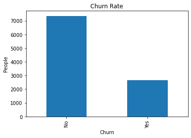

```python
# Churn Data
churn_data = df['Churn'].value_counts()
churn_data.plot(kind='bar')
plt.title('Churn Rate')
plt.xlabel('Churn')
plt.ylabel('People')
plt.show()
```

> Amount of either yes churn or no churn

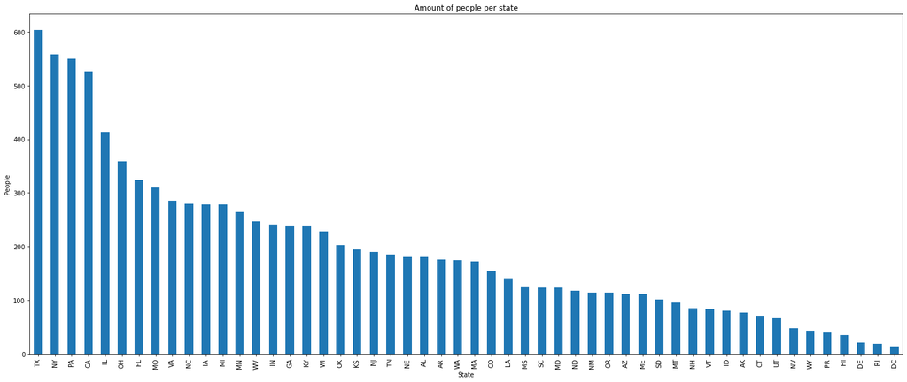

```python
# State Data
state_data = df['State'].value_counts()
state_data.plot(kind='bar',figsize=(25,10))
plt.title('Amount of people per state')
plt.xlabel('State')
plt.ylabel('People')
plt.show()
```

> Amount of people per state

### Continuous

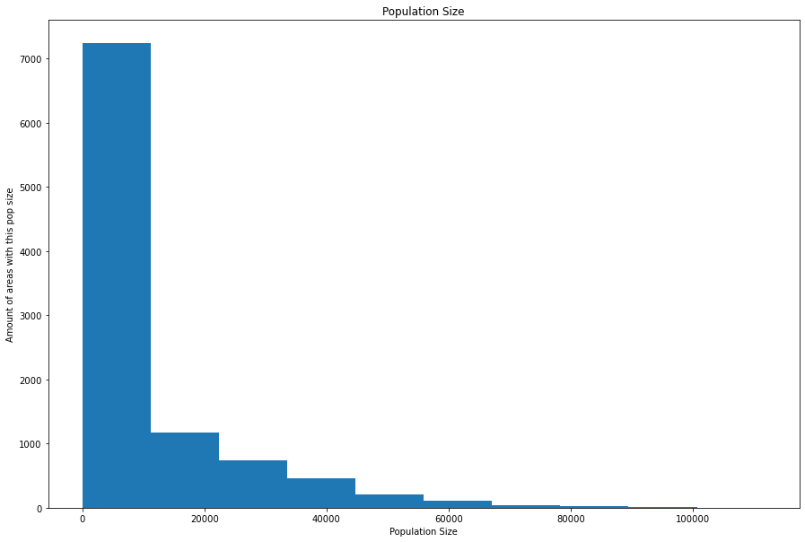

```python
# Population Data
population_data = df['Population']
population_data.plot(kind='hist',figsize=(15,10))
plt.title('Population Size')
plt.xlabel('Population Size')
plt.ylabel('Amount of areas with this pop size')
plt.show()
```

> Population size and amount of areas with that population size

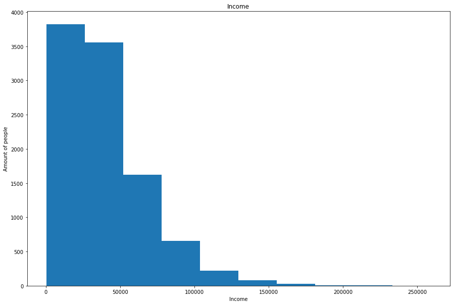

```python
# Income Data
population_data = df['Income']
population_data.plot(kind='hist',figsize=(15,10))
plt.title('Income')
plt.xlabel('Income')
plt.ylabel('Amount of people')
plt.show()
```

> Income levels and the amount of individuals who have that income

## Bivariate Analysis

### Categorical

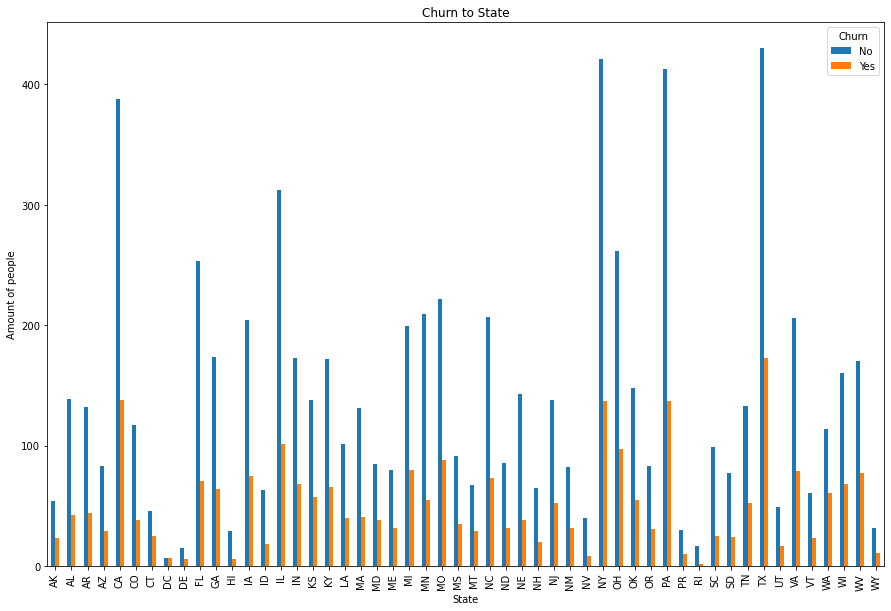

```python
# Churn to State data
group_churn_state = df.groupby(['State','Churn']).size()
group_churn_state = group_churn_state.unstack()
group_churn_state.plot(kind='bar',figsize=(15,10))
plt.title('Churn to State')
plt.xlabel('State')
plt.ylabel('Amount of people')
plt.show()
```

> Showing the amount of yes churn and no churn for each individual state

### Continuous

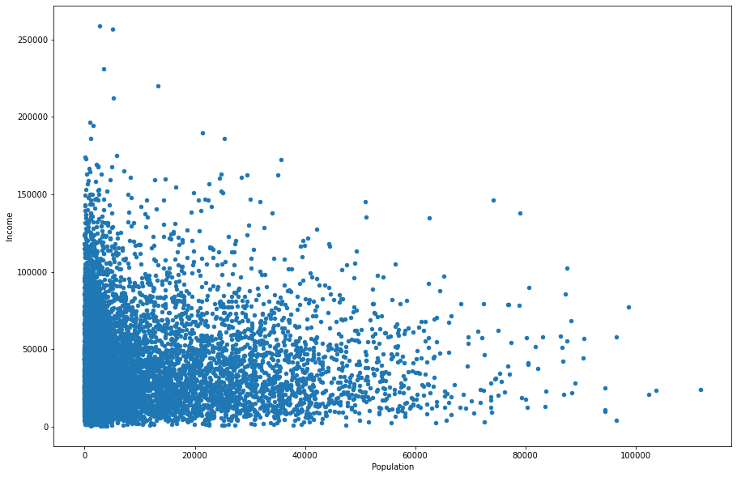

```python
# Population to income data
df.plot(kind='scatter', x='Population', y='Income',figsize=(15,10))
plt.show()
```

> Showing the population to income in a scatter plot

> The results of the hypothesis test show that typically the higher tenure and bandwidth usage, the lower the churn rate.

> The more data a customer uses, and the longer they stay, reduces the possibility that they will leave in the future.

> The limitations of this analysis is that we only used a T-Test analysis on several variables.

> To make the analysis more secure in the results, you would want to run multiple different types of tests on many different variables. The more data that is tested and analyzed, the more likely the results will be correct.

> A course of action a company could take based on this information, is that they could specifically try to keep customers in the short term and have them use more data. They could have new customer deals and potentially make the first few months of usage cost less, so the customers will use more. This would potentially make them have a lower likelihood of leaving at some point in the future.